# Brownian Motion

# Brownian Motion Context

We say that a stochastic process $(W_t)_{t\ge0}$ is a standard Brownian Motion if:

- $W_0=0$
- $t\rightarrow W_t$ are continuous
- The increments are independent: $\forall 0\le s\le t, W_t-W_s$ is independent of $W_s$
  - same with $t_1\le t_2\le\ldots\le t_k,(W_{t_i+x} -W_{t+i})_{x\in[1, k]}$ are independent
- The law of $W_t-W_s$ is $\mathcal{N}(0, t-s)$.

## Simulating Brownian Motions

### GOAL

We are interested in implementing a Brownian Motion process model using two different algorithms.

### METHOD

Simulation method 1:

We simulate a Brownian Motion trajectory by:

1. Introducing a time length $n$ and a time step $t_i,\,\forall i [0,n]$ such that $t_i=\eta.i$ with $\eta$ a fixed, discretization timestep
2. We set $W_0=0$
3. We set $W_{t_1}=\sqrt{t_1}.\mathcal{N}(0, 1)$
4. Then, $\forall i\in[2,\frac{T_{max}}{\eta}],\,W_{t_i}=W_{t_i-1}+\sqrt{t_i-t_{i-1}}.\mathcal{N}(0, 1)$

Simulation method 2:

We can also rely on [Donsker’s Theorem](https://en.wikipedia.org/wiki/Donsker%27s_theorem):

1. Let $X_1, X_2, \ldots$ be a sequence of IID random variable with mean 0 and variance 1 (in our case, $\forall i \in \{1, 2, \ldots\},\,X_i\in\{-1, 1\}$ and $P(X_i=1)=P(X_i=-1)=\frac{1}{2}$).
2. Let $n\in\mathbb{N},\,S_n = \underset{i=1}{\overset{n}{\sum}}X_i$ be the stochastic process known as a random walk
3. Let the diffusively rescaled random walk (partial sum process) $W^{(n)}(t)$ such that:

$$W^{(n)}(t)=\frac{1}{\sqrt{n}}.S_{\lfloor nt\rfloor},\,t\in[0,1]$$

Function implementations:

```r
standard_simulation <- function(n, eta, graph=F) {
  ### Simulate a brownian motion using an iterative process
  timesteps = seq(0, n, eta)
  # Initializes the brownian motion
  w0 = 0
  w1 = sqrt(eta) * rnorm(1)
  brownian_motion = c(w0, w1)
  # Populates the brownian motion
  for (i in timesteps[3:length(timesteps)]) { # /!\ R is 1-valued
    new_step = brownian_motion[length(brownian_motion)] + sqrt(eta) * rnorm(1)
    brownian_motion = c(brownian_motion, new_step)
  }
  if (graph) {
    plot(timesteps, brownian_motion, type="l",
         main="Simulated browian motion",
         xlab="n", ylab="W_t")
  }
  brownian_motion
}

donsker_simulation <- function(n, eta, graph=F) {
  ### Simulate a brownian motion based on donsker's theorem
  timesteps = seq(0, 1, eta)
  # Computes the steps of a donsker-based brownian motion
  X = sample(c(-1, 1), n, T, prob = c(1/2, 1/2))
  S = cumsum(X)
  W = unlist(apply(matrix(timesteps), 1, function(x) {1/sqrt(n)*S[round(n*x)]}))
  if (graph) {
    par(mar=c(2.5,2.5,2.5,2.5)) # deals with margin error
    plot(timesteps, c(0, W), type="l",
         main="Simulated browian motion via Donsker's Theorem",
         xlab="n", ylab="W_t")
  }
  c(0, W)
}

simulate <- function (simulation_function, n_simulations, time_length, timestep, donsker_n=NULL) {
  ### Simulate a set of brownian motions and display the results given a
  ### simulation method.
  time_range = seq(0, time_length, timestep)
  simulations = c()
  # Computes the simulations
  for (sim in 1:n_simulations) {
    if (simulation_function == "standard") {
      s = standard_simulation(time_length, timestep)
      title = "simulated Brownian Motions"
    } else {
      if (is.null(donsker_n)) {
        donsker_n = time_length/timestep
      }
      s = donsker_simulation(donsker_n, timestep)
      title = "Brownian Motions (simulated via Donsker's Theorem)"
    }
    simulations = c(simulations, s)
  }
  simulations = t(matrix(simulations, ncol=n_simulations))
  # Plots
  ylim = c(min(simulations), max(simulations))
  plot(time_range, simulations[1,], col=2, type="l", ylim=ylim,
       xlab="n", ylab="W_t",
       main=paste("Set of", n_simulations, title,
                  "\nwith parameters n =", time_length, ", eta =", timestep))
  for (sim in 2:n_simulations) {
    lines(time_range, simulations[sim,], col=sim+1)
  }
  simulations
}
```

### RESULTS - Simulation with Algorithm 1

We generate 10 brownian motions with parameters $n=10$ and $\eta=0.1$.

```r
algo1_simulations = simulate("standard", 10, 10, 0.1)
```

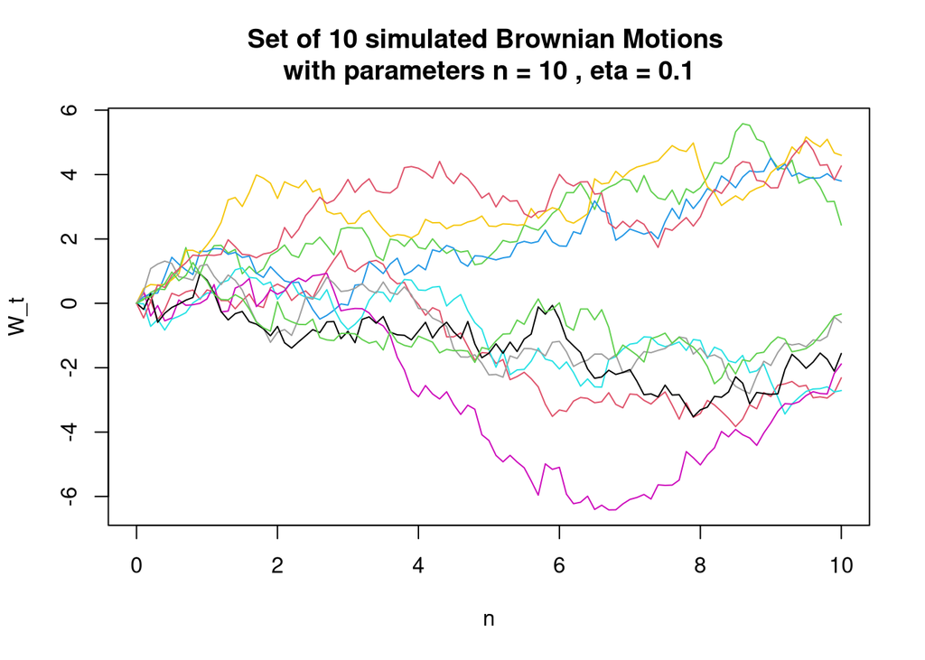

We generate 10 brownian motions with parameters $n=10$ and $\eta=0.01$.

```r
algo1_simulations = simulate("standard", 10, 10, 0.01)
```

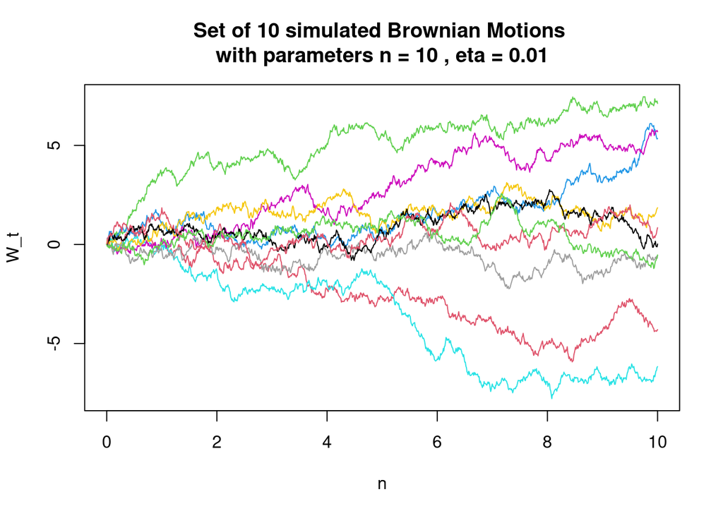

We generate 10 brownian motions with parameters $n=100$ and $\eta=0.1$.

```r
algo1_simulations = simulate("standard", 10, 100, 0.1)
```

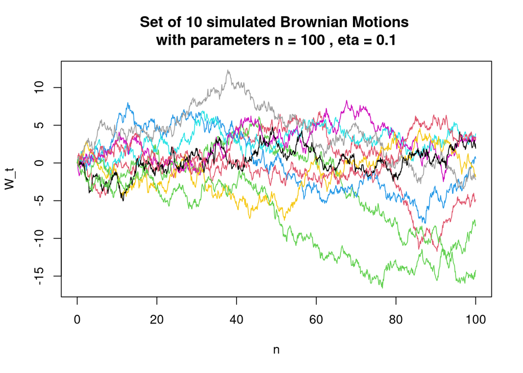

### RESULTS - Simulation with Algorithm 2

We generate 10 brownian motions with parameters $donsker_n=100$ and $\eta=0.1$, using the Donsker’s theorem.

```r
# Note: by the Donsker's theorem, the time length is set to 1
algo2_simulations = simulate("donsker", 10, time_length=1, 0.1, donsker_n=100)
```

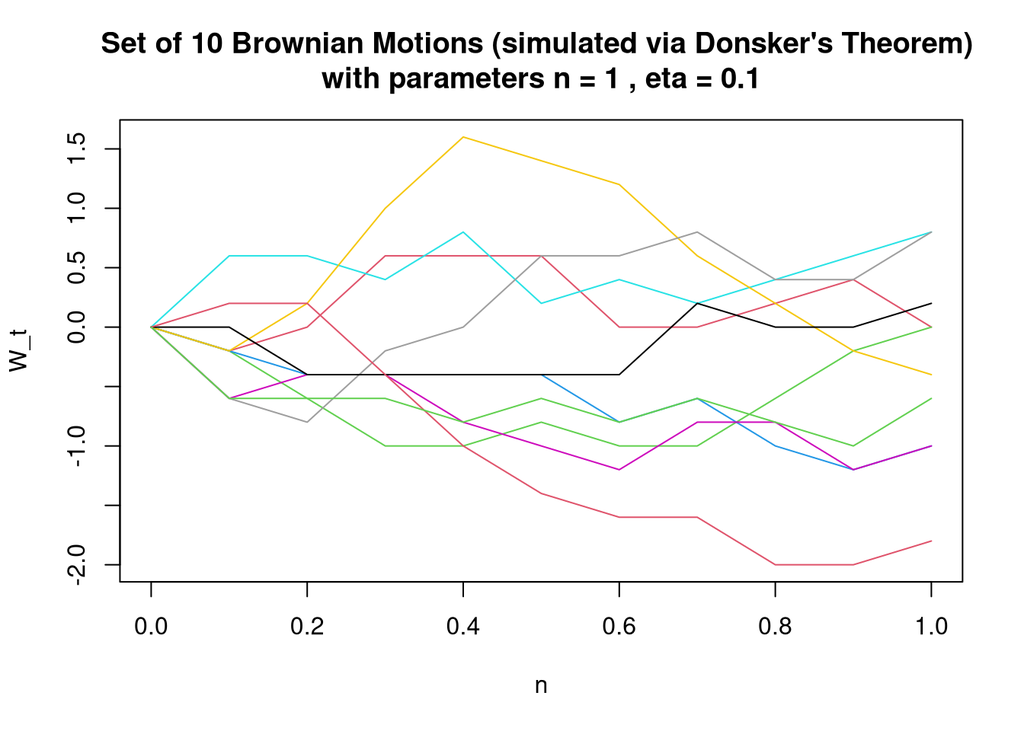

We generate 10 brownian motions with parameters $donsker_n=10000$ and $\eta=0.1$, using the Donsker’s theorem.

```r
# Note: by the Donsker's theorem, the time length is set to 1
algo2_simulations = simulate("donsker", 10, time_length=1, 0.1, donsker_n=10000)
```

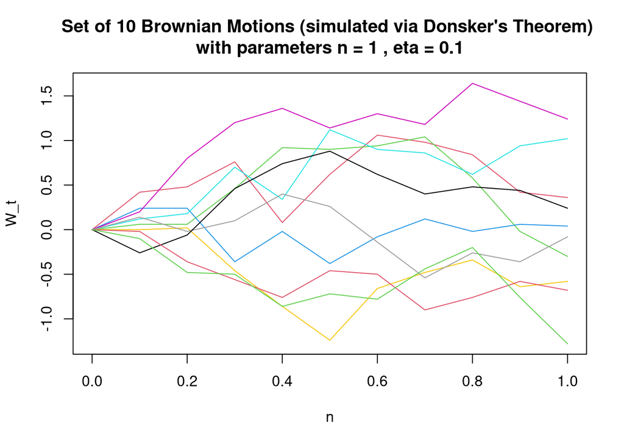

We generate 10 brownian motions with parameters $donsker_n=10$ and $\eta=0.1$, using the Donsker’s theorem.

```r
# Note: by the Donsker's theorem, the time length is set to 1
algo2_simulations = simulate("donsker", 10, time_length=1, 0.1, donsker_n=10)
```

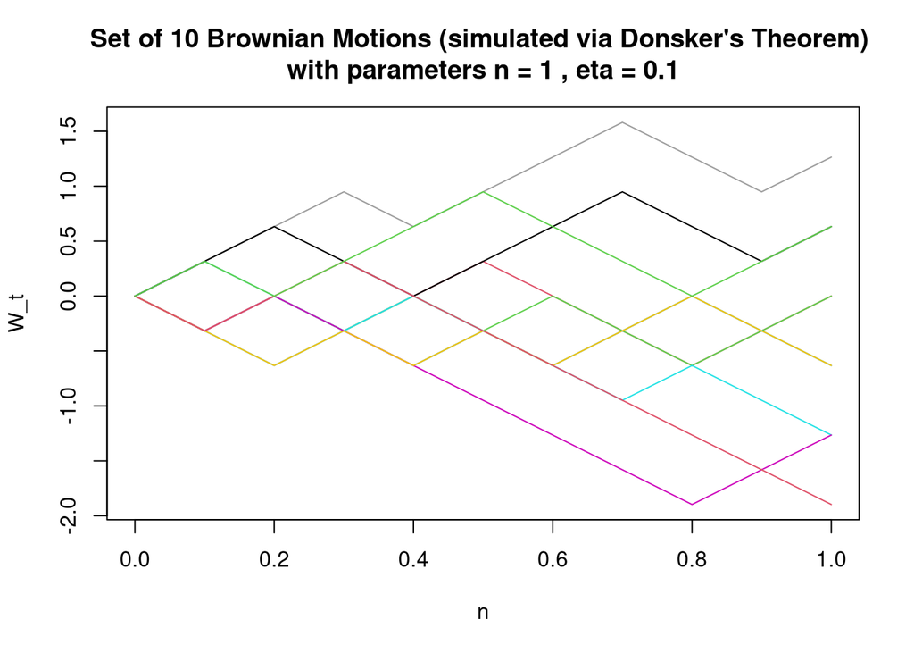

We generate 10 brownian motions with parameters $donsker_n=100$ and $\eta=0.01$, using the Donsker’s theorem.

```r
# Note: by the Donsker's theorem, the time length is set to 1
algo2_simulations = simulate("donsker", 10, time_length=1, 0.01, donsker_n=100)
```

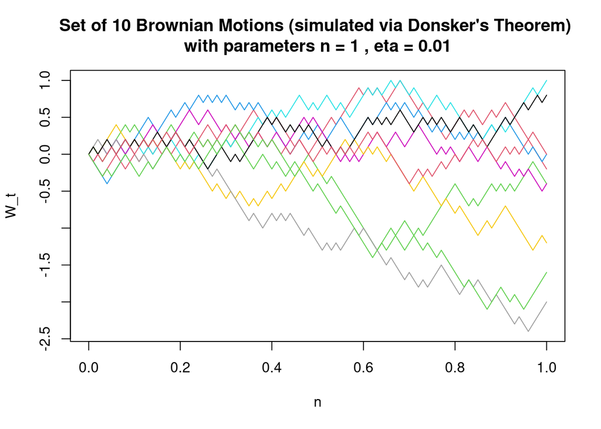

We generate 10 brownian motions with parameters $donsker_n=1000$ and $\eta=0.01$, using the Donsker’s theorem.

```r
# Note: by the Donsker's theorem, the time length is set to 1
algo2_simulations = simulate("donsker", 10, time_length=1, 0.01, donsker_n=1000)
```

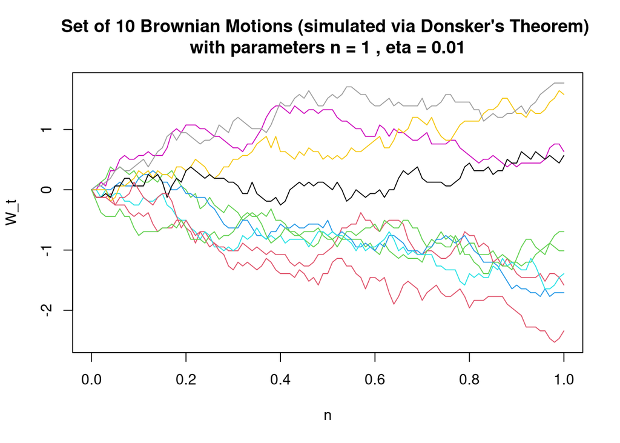

We generate 10 brownian motions with parameters $donsker_n=10000$ and $\eta=0.01$, using the Donsker’s theorem.

```r
# Note: by the Donsker's theorem, the time length is set to 1
algo2_simulations = simulate("donsker", 10, time_length=1, 0.01, donsker_n=10000)
```

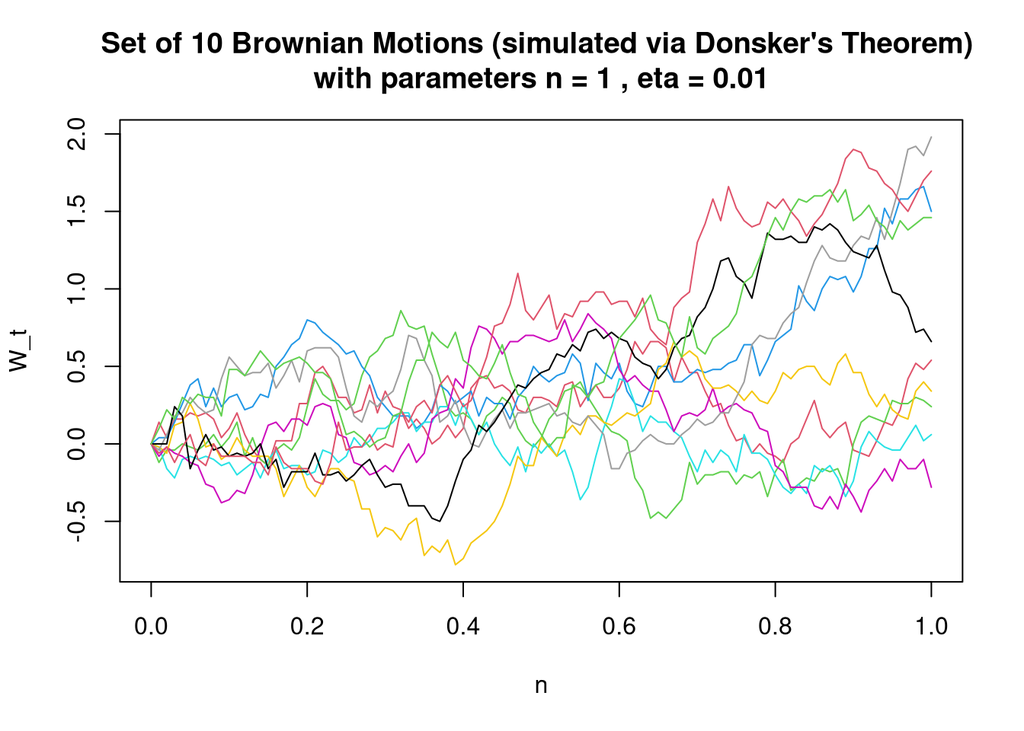

We generate 10 brownian motions with parameters $donsker_n=10000$ and $\eta=0.0001$, using the Donsker’s theorem.

```r
# Note: by the Donsker's theorem, the time length is set to 1
algo2_simulations = simulate("donsker", 10, time_length=1, 0.0001, donsker_n=10000)
```

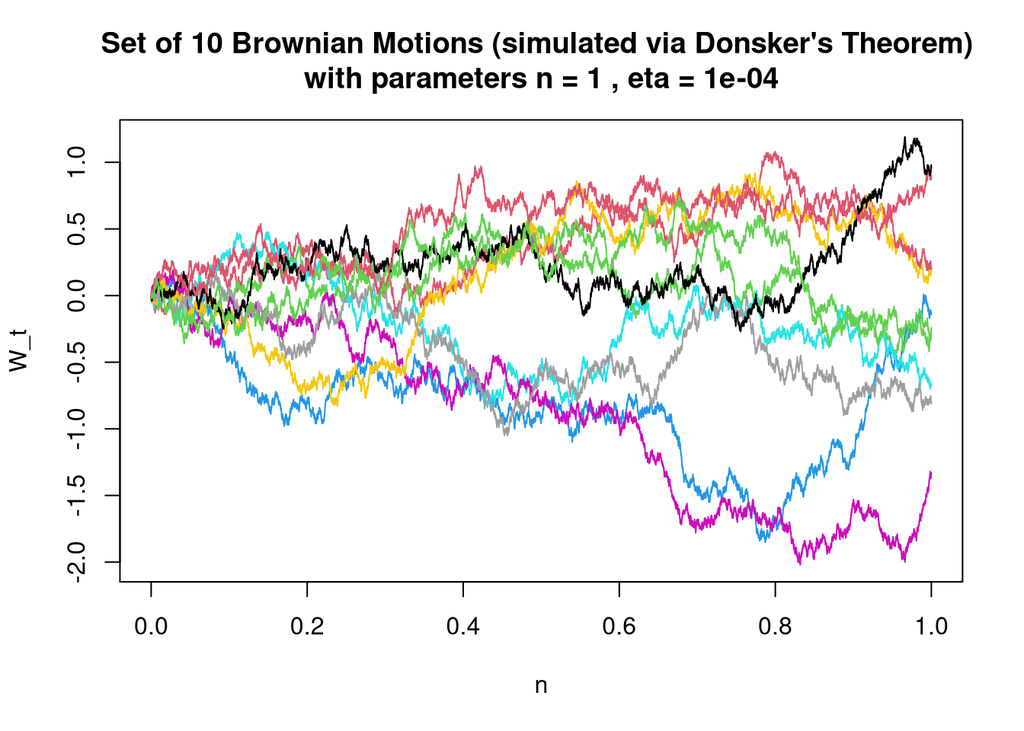

### COMMENTS

We have shown two ways to yield a Brownian Motion. It is interesting to note that the algorithm relying on the Donsker’s Theorem only produces a Brownian Motion on the interval $[0, 1]$ with a resulting range for $W_t$ restricted around a mean of 0.

In order to obtain a Brownian Motion on a larger scale (e.g. $n\in[0, 10]$), it is interesting to consider how to rescale the resulting simulations (whether we only scale the $x$-axis, or whether we should rescale both $x$ and $y$-axes).